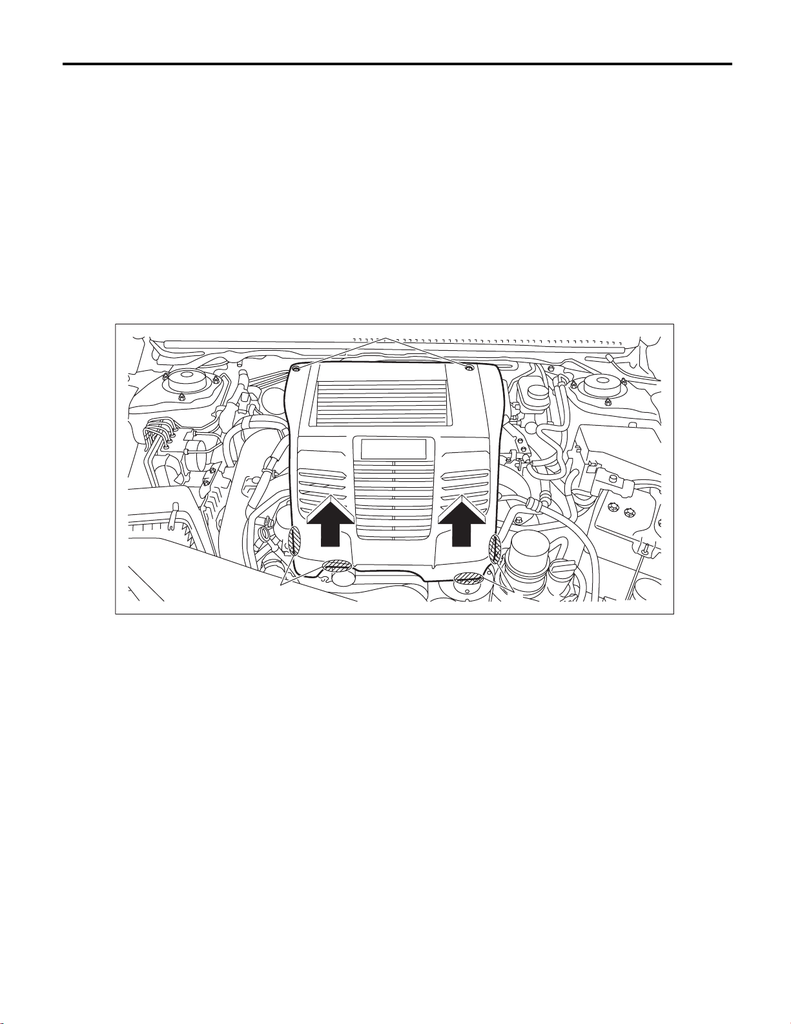

ME(w/o STI)-36

Cam Clearance

MECHANICAL

8. Cam Clearance

A: INSPECTION

1. WHEN TIMING CHAIN ASSEMBLY IS NOT REMOVED

CAUTION:

When working on the vehicle, if engine oil is spilt onto the exhaust pipe, wipe it off with cloth to avoid

emission of smoke or causing a fire.

NOTE:

• Inspection of cam clearance should be performed while engine is cold.

• If the engine is removed from vehicle, performing the step 1) is not necessary.

1) Remove the collector cover.

(1) Remove the clips (A).

(2) Hold the shaded area (B) by hand and carefully pull the RH side (C) upward.

(3) Hold the shaded area (D) by hand and carefully pull the LH side (E) upward.

2) Remove the V-belts. <Ref. to ME(w/o STI)-78, REMOVAL, V-belt.>

EX-03204

(A)

(B)

(C)

(E)

(D)

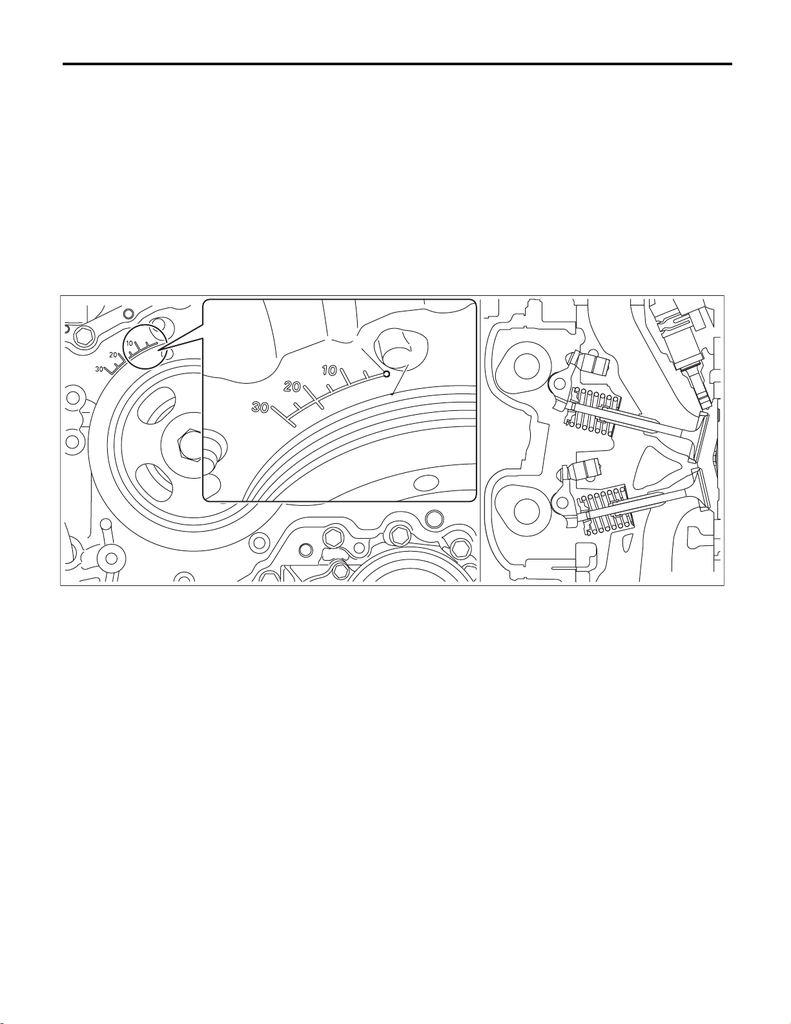

ME(w/o STI)-37

Cam Clearance

MECHANICAL

3) When inspecting #1 and #3 cylinders

(1) Remove the rocker cover RH. <Ref. to ME(w/o STI)-152, ROCKER COVER RH, REMOVAL, Rocker

Cover.>

NOTE:

When working on the vehicle, place a suitable container under the vehicle.

(2) Set #1 cylinder piston to top dead center of compression stroke by rotating the crank pulley clockwise

using the socket wrench.

NOTE:

When the timing mark (A) on crank pulley is aligned to the 0° in timing gauge (B) on chain cover as shown

in the figure, the #1 cylinder piston is located at TDC of compression stroke if the intake camshaft and ex-

haust camshaft does not depress the #1 cylinder intake side roller rocker arm (intake valve) and exhaust side

roller rocker arm (exhaust valve). If roller rocker arm (valve) is depressed, turn the crank pulley by 360° in or-

der to make #1 cylinder piston at TDC of compression stroke.

ME-07465

(A)

(B)

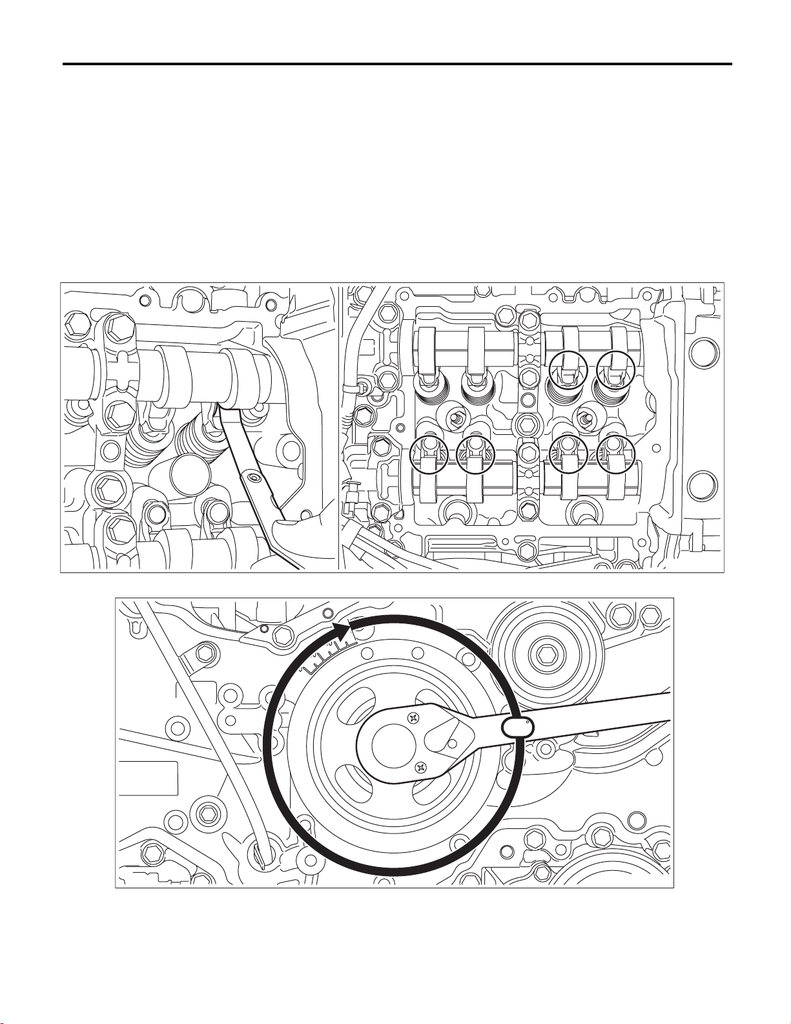

ME(w/o STI)-38

Cam Clearance

MECHANICAL

(3) Check the cam clearance for #1 cylinder intake, #1 cylinder exhaust and #3 cylinder exhaust.

NOTE:

• Measure the roller surface of cam base circle and roller rocker arm using thickness gauge (A).

• If the measured value is out of standard, take notes of the value in order to adjust the cam clearance later

on.

Cam clearance:

Intake

Standard

0.13

+0.02

–0.03

mm (0.0051

+0.0008

–0.0012

in)

Exhaust

Standard

0.22

±

0.02 mm (0.0087

±

0.0008 in)

(4) Turn the crank pulley by 360°.

ME-06653

(A)

ME-06654

360

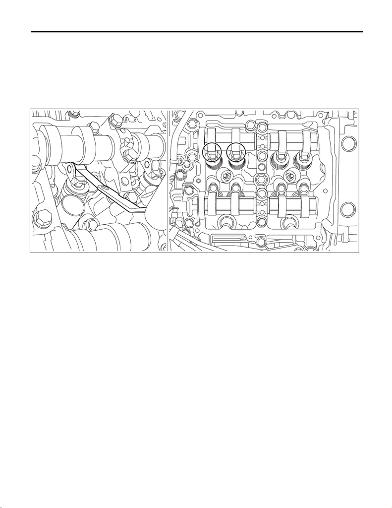

ME(w/o STI)-39

Cam Clearance

MECHANICAL

(5) Check the clearance of #3 cylinder intake.

NOTE:

• Measure the roller surface of cam base circle and roller rocker arm using thickness gauge (A).

• If the measured value is out of standard, take notes of the value in order to adjust the cam clearance later

on.

Cam clearance:

Standard

0.13

+0.02

–0.03

mm (0.0051

+0.0008

–0.0012

in)

ME-06655

(A)

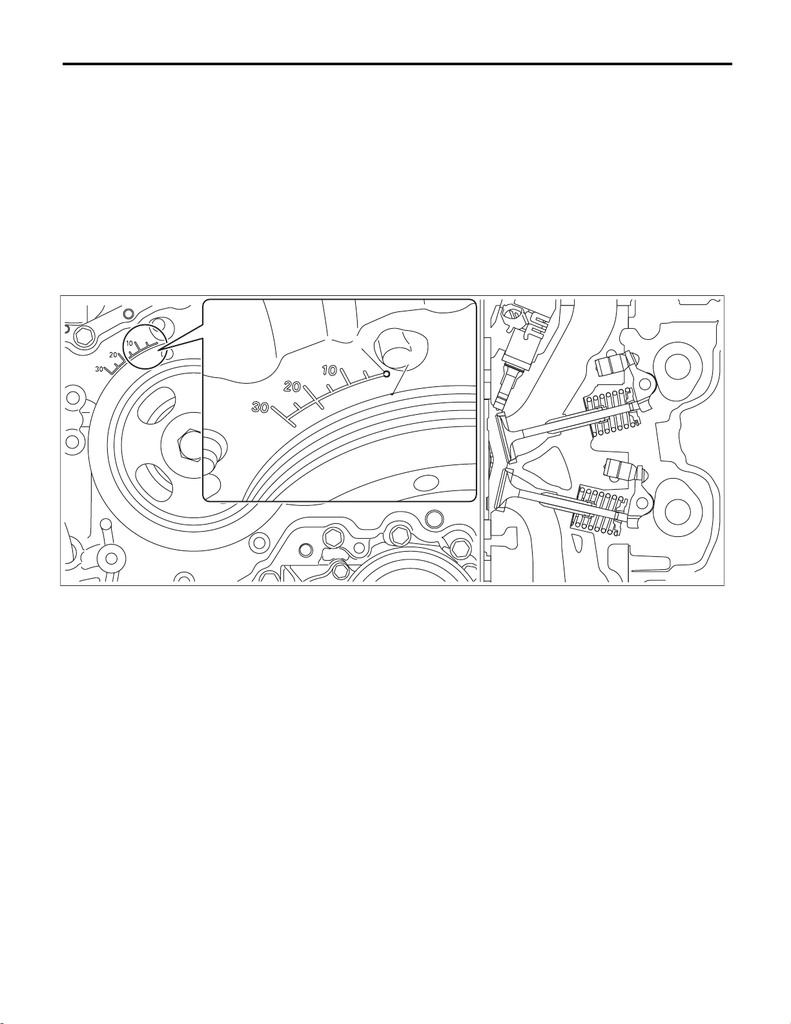

ME(w/o STI)-40

Cam Clearance

MECHANICAL

4) When inspecting #2 and #4 cylinders

(1) Remove the rocker cover LH. <Ref. to ME(w/o STI)-154, ROCKER COVER LH, REMOVAL, Rocker

Cover.>

NOTE:

When working on the vehicle, place a suitable container under the vehicle.

(2) Set #2 cylinder piston to top dead center of compression stroke by rotating the crank pulley clockwise

using the socket wrench.

NOTE:

When the timing mark (A) on crank pulley is aligned to the 0° in timing gauge (B) on chain cover as shown

in the figure, the #2 cylinder piston is located at TDC of compression stroke if the intake camshaft and ex-

haust camshaft does not depress the #2 cylinder intake side roller rocker arm (intake valve) and exhaust side

roller rocker arm (exhaust valve). If roller rocker arm (valve) is depressed, turn the crank pulley by 360° in or-

der to make #2 cylinder piston at TDC of compression stroke.

ME-07466

(A)

(B)

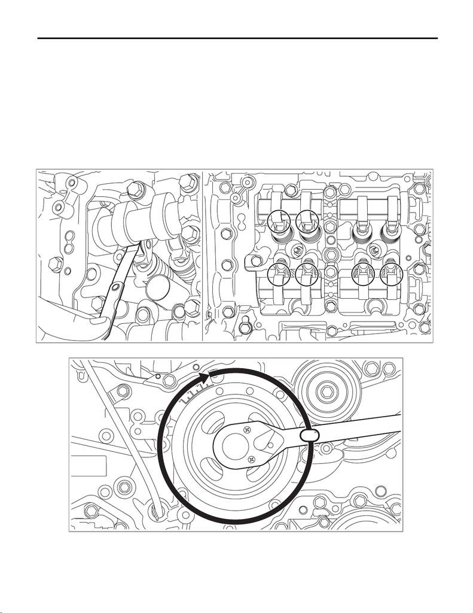

ME(w/o STI)-41

Cam Clearance

MECHANICAL

(3) Check the cam clearance for #2 cylinder intake, #2 cylinder exhaust and #4 cylinder exhaust.

NOTE:

• Measure the roller surface of cam base circle and roller rocker arm using thickness gauge (A).

• If the measured value is out of standard, take notes of the value in order to adjust the cam clearance later

on.

Cam clearance:

Intake

Standard

0.13

+0.02

–0.03

mm (0.0051

+0.0008

–0.0012

in)

Exhaust

Standard

0.22

±

0.02 mm (0.0087

±

0.0008 in)

(4) Turn the crank pulley by 360°.

ME-06657

(A)

ME-06654

360

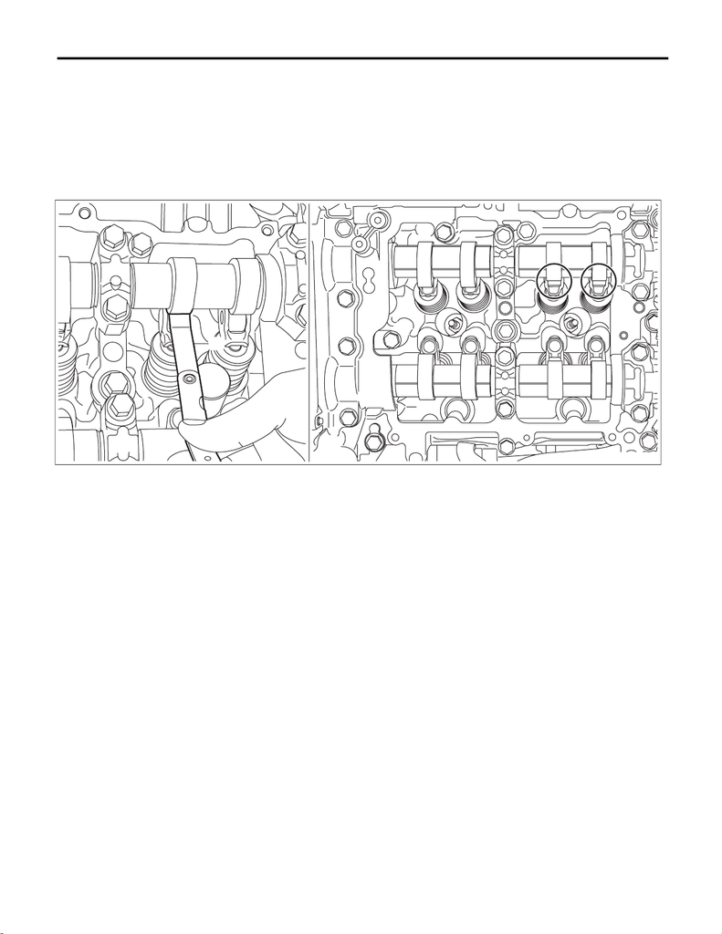

ME(w/o STI)-42

Cam Clearance

MECHANICAL

(5) Check the clearance of #4 cylinder intake.

NOTE:

• Measure the roller surface of cam base circle and roller rocker arm using thickness gauge (A).

• If the measured value is out of standard, take notes of the value in order to adjust the cam clearance later

on.

Cam clearance:

Standard

0.13

+0.02

–0.03

mm (0.0051

+0.0008

–0.0012

in)

5) If necessary, adjust the cam clearance. <Ref. to ME(w/o STI)-45, ADJUSTMENT, Cam Clearance.>

6) After inspection, install the related parts in the reverse order of removal.

ME-06658

(A)

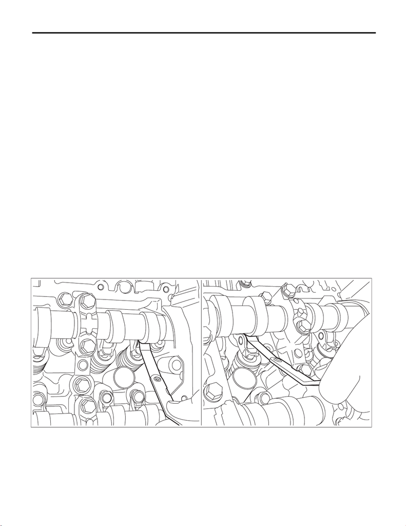

ME(w/o STI)-43

Cam Clearance

MECHANICAL

2. WHEN TIMING CHAIN ASSEMBLY IS REMOVED

NOTE:

Inspection of cam clearance should be performed while engine is cold.

1) When inspecting #1 and #3 cylinders

(1) Remove the rocker cover RH. <Ref. to ME(w/o STI)-152, ROCKER COVER RH, REMOVAL, Rocker

Cover.>

NOTE:

When working on the vehicle, place a suitable container under the vehicle.

(2) Check the #1 and #3 cylinder cam clearance.

CAUTION:

Intake and exhaust camshafts can be independently rotated with the timing chain removed. When the

intake valve and exhaust valve lift at the same time, the valve heads contact each other and valve

stem may bend. Do not turn it to the outside of range of zero lift (cam base circle position) (in range

where it can be turned lightly by hand).

NOTE:

• For cam clearance inspection, adjust the cam base circle position so that the thickness gauge (A) can be

inserted easily by hand turning the camshaft (cam sprocket) to be measured.

• Measure the roller surface of cam base circle and roller rocker arm using thickness gauge (A).

• If the measured value is out of standard, take notes of the value in order to adjust the cam clearance later

on.

Cam clearance:

Intake

Standard

0.13

+0.02

–0.03

mm (0.0051

+0.0008

–0.0012

in)

Exhaust

Standard

0.22

±

0.02 mm (0.0087

±

0.0008 in)

ME-06659

(A)

(A)

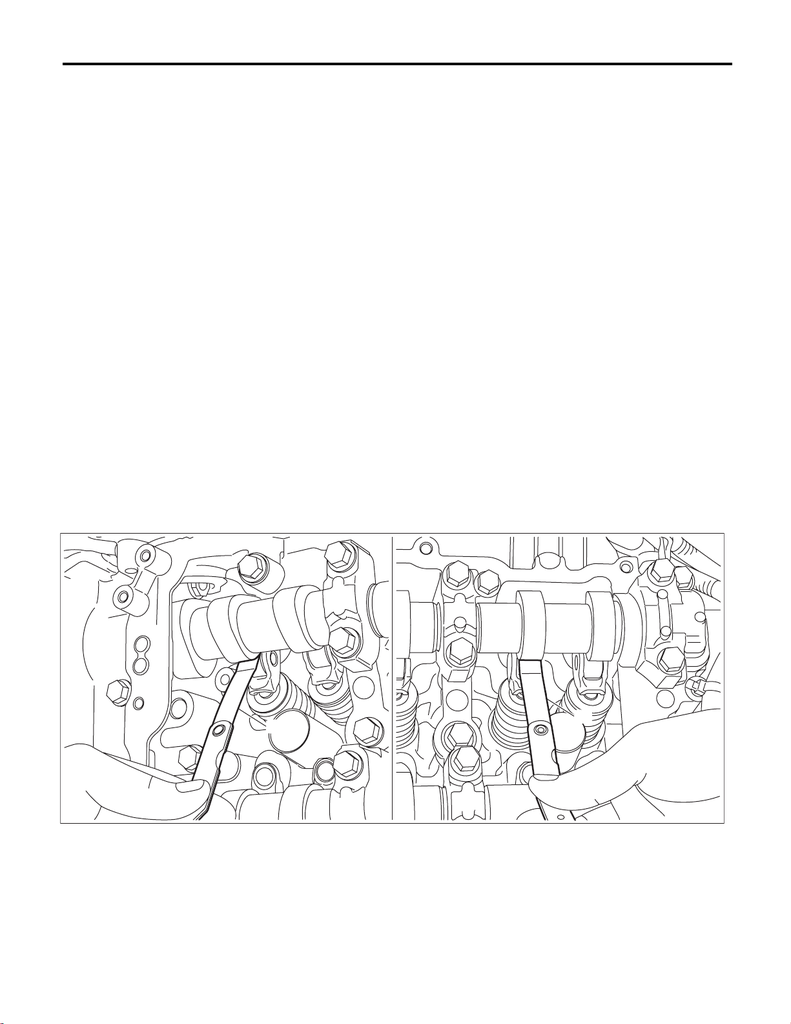

ME(w/o STI)-44

Cam Clearance

MECHANICAL

2) When inspecting #2 and #4 cylinders

(1) Remove the rocker cover LH. <Ref. to ME(w/o STI)-154, ROCKER COVER LH, REMOVAL, Rocker

Cover.>

NOTE:

When working on the vehicle, place a suitable container under the vehicle.

(2) Check the #2 and #4 cylinder cam clearance.

CAUTION:

Intake and exhaust camshafts can be independently rotated with the timing chain removed. When the

intake valve and exhaust valve lift at the same time, the valve heads contact each other and valve

stem may bend. Do not turn it to the outside of range of zero lift (cam base circle position) (in range

where it can be turned lightly by hand).

NOTE:

• Because the intake camshaft is pressurized by the high-pressure fuel pump, it is almost impossible to turn

the intake camshaft lightly by hand. Since the zero-lift position is adjusted at the removal of the timing chain

LH, measure the cam clearance at that position.

• For cam clearance inspection on exhaust side, adjust the cam base circle position so that the thickness

gauge (A) can be inserted easily by hand turning the exhaust camshaft (cam sprocket).

• Measure the roller surface of cam base circle and roller rocker arm using thickness gauge (A).

• If the measured value is out of standard, take notes of the value in order to adjust the cam clearance later

on.

Cam clearance:

Intake

Standard

0.13

+0.02

–0.03

mm (0.0051

+0.0008

–0.0012

in)

Exhaust

Standard

0.22

±

0.02 mm (0.0087

±

0.0008 in)

3) If necessary, adjust the cam clearance. <Ref. to ME(w/o STI)-45, ADJUSTMENT, Cam Clearance.>

4) After inspection, install the related parts in the reverse order of removal.

ME-06660

(A)

(A)

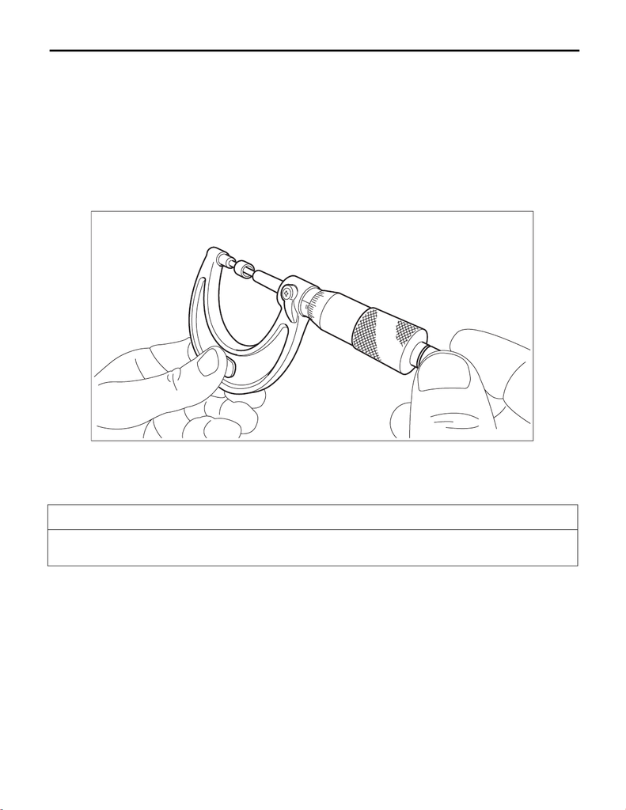

ME(w/o STI)-45

Cam Clearance

MECHANICAL

B: ADJUSTMENT

1) Remove the engine from the vehicle. <Ref. to ME(w/o STI)-48, REMOVAL, Engine Assembly.>

2) Remove the chain cover. <Ref. to ME(w/o STI)-93, REMOVAL, Chain Cover.>

3) When adjusting #1 and #3 cylinders

(1) Remove the timing chain RH. <Ref. to ME(w/o STI)-116, TIMING CHAIN RH, REMOVAL, Timing

Chain Assembly.>

(2) Remove the cam carrier RH. <Ref. to ME(w/o STI)-172, CAM CARRIER RH, REMOVAL, Cam Car-

rier.>

(3) Measure the thickness of valve shim using micrometer.

NOTE:

Measurement should be performed at a temperature of 20°C (68°F).

(4) Select a valve shim of suitable thickness using the measured cam clearance and valve shim thick-

ness.

NOTE:

Use a new valve shim.

(5) Install the cam carrier RH. <Ref. to ME(w/o STI)-180, CAM CARRIER RH, INSTALLATION, Cam Car-

rier.>

Intake side: S = T + 1.69 × (V – 0.13 mm (0.0051 in))

Exhaust side: S = T + 1.87 × (V – 0.22 mm (0.0087 in))

S: Valve shim thickness required

V: Measured cam clearance

T: Current valve shim thickness

ME-05085

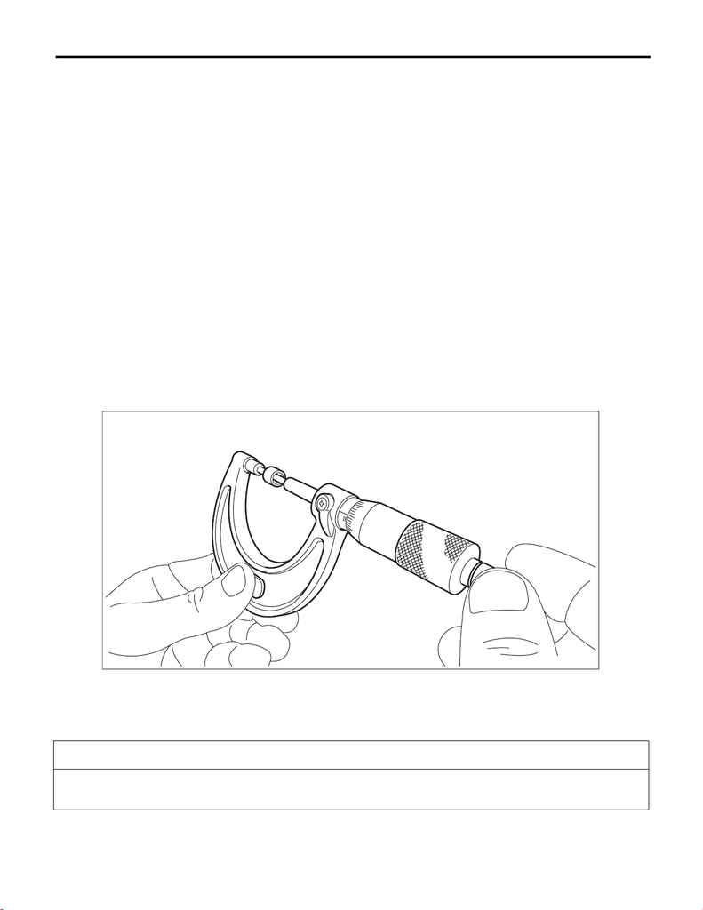

ME(w/o STI)-46

Cam Clearance

MECHANICAL

(6) Check all the cam clearance of RH side at this time. If the cam clearance is not within the standard val-

ue, repeat the procedure over again from step 2).

NOTE:

When the removing/installing of cam carrier RH has been performed, cam clearance may be outside the

standard value. Checking of all cam clearance of RH side is necessary. Refer to INSPECTION of “Cam

Clearance” for the cam clearance inspection. <Ref. to ME(w/o STI)-43, WHEN TIMING CHAIN ASSEMBLY

IS REMOVED, INSPECTION, Cam Clearance.>

Cam clearance:

Intake

Standard

0.13

+0.02

–0.03

mm (0.0051

+0.0008

–0.0012

in)

Exhaust

Standard

0.22

±

0.02 mm (0.0087

±

0.0008 in)

4) When adjusting #2 and #4 cylinders

(1) Remove the timing chain LH. <Ref. to ME(w/o STI)-119, TIMING CHAIN LH, REMOVAL, Timing

Chain Assembly.>

(2) Remove the intake manifold. <Ref. to FU(w/o STI)-18, REMOVAL, Intake Manifold.>

(3) Remove the cam carrier LH. <Ref. to ME(w/o STI)-175, CAM CARRIER LH, REMOVAL, Cam Carri-

er.>

(4) Measure the thickness of valve shim using micrometer.

NOTE:

Measurement should be performed at a temperature of 20°C (68°F).

(5) Select a valve shim of suitable thickness using the measured cam clearance and valve shim thick-

ness.

NOTE:

Use a new valve shim.

(6) Install the cam carrier LH. <Ref. to ME(w/o STI)-190, CAM CARRIER LH, INSTALLATION, Cam Car-

rier.>

Intake side: S = T + 1.69 × (V – 0.13 mm (0.0051 in))

Exhaust side: S = T + 1.87 × (V – 0.22 mm (0.0087 in))

S: Valve shim thickness required

V: Measured cam clearance

T: Current valve shim thickness

ME-05085

[figure not shown]

ME(w/o STI)-47

Cam Clearance

MECHANICAL

(7) Check all the cam clearance of LH side at this time. If the cam clearance is not within the standard val-

ue, repeat the procedure over again from step 3).

NOTE:

When the removing/installing of cam carrier LH has been performed, cam clearance may be outside the stan-

dard value. Checking of all cam clearance of LH side is necessary. Refer to INSPECTION of “Cam Clear-

ance” for the cam clearance inspection. <Ref. to ME(w/o STI)-43, WHEN TIMING CHAIN ASSEMBLY IS

REMOVED, INSPECTION, Cam Clearance.>

Cam clearance:

Intake

Standard

0.13

+0.02

–0.03

mm (0.0051

+0.0008

–0.0012

in)

Exhaust

Standard

0.22

±

0.02 mm (0.0087

±

0.0008 in)

5) After adjustment, install the related parts in the reverse order of removal.